# Environment, Packages, Functions, Import/Export

Enrico Toffalini

## Install packages… and more

Most of the data analysis tasks you will perform won’t come from base R: you will most often load additional **packages** for specialized functions

Install a package from CRAN

```r
install.packages("effsize")
```

Simultaneously install multiple packages

```r
install.packages( c("effsize","psych","ggplot2") )
```

For development or personal use, you may occasionally install packages from outside CRAN, such as from GitHub:

```r
devtools::install_github("FilippoGambarota/filor")
devtools::install_github("EnricoToffalini/toffee")
```

After installing, you need to load the packages using the `library()` function:

```r
library(effsize)
library(ggplot2)
```

## Install packages… and more

### call functions

After loading a package, its functions are directly callable throughout the R session:

```r
library(psych)

fisherz(rho=0.5) # use a function from the "psych" package
```

```
[1] 0.5493061
```

You may directly call any function from any installed package, even without loading it, using “**`::`**”; this is especially useful when there is a risk of functions with conflicting names, or if you just don’t want to load an entire package to use a single function:

```r
psych::fisherz(rho=0.5)
```

```
[1] 0.5493061
```

#### Some R packages that you will or may need in the future (1/3)

| Package | Used for what | Examples of functions |
| --- | --- | --- |
| `base` (base R) | Basic functions | `sum`, `mean`, `sqrt`, `abs`, `c`, `data.frame`, `summary`, `scale`, `plot`, `+`, `-` |
| `stats` (base R) | Basic statistical calculations and functions | `sd`, `cor`, `cor.test`, `t.test`, `lm`, `glm`, `AIC`, `rnorm`, `rbinom` |
| `graphics` (base R) | Basic plotting functions | `plot`, `boxplot`, `hist`, `barplot` |

*(You may actually use these “base” packages very often without even realizing that they are packages)*

#### Some R packages that you will or may need in the future (2/3)

| Package | Used for what | Examples of functions |
| --- | --- | --- |
| `lme4` | Fitting (generalized) (non-)linear mixed-effects models | `lmer`, `glmer`, `ranef` |
| `performance` | Useful tools for models | `check_collinearity`, `r2_nagelkerke`, `icc` |
| `effects` | Display effects for various statistical models | `allEffects`, `effect` |
| `emmeans` | Estimate marginal means for various models | `emmeans` |
| `effectsize` | Compute or convert different effect sizes | `cohens_d`, `hedges_g`, `cohens_f`, `d_to_r` |

#### Some R packages that you will or may need in the future (3/3)

| Package | Used for what | Examples of functions |
| --- | --- | --- |
| `ggplot2` | Create beautiful plots using The Grammar of Graphics | `ggplot`, `geom_point`, `geom_line`, … |
| `lavaan` | Structural Equation Models (SEM) | `sem`, `cfa` |
| `semTools` | Useful tools for SEMs | `compRelSEM`, `measEq.syntax` |
| `metafor` | Perform meta-analysis | `rma`, `rma.mv`, `forest`, `funnel`, `regtest` |
| `brms` | Fitting practically any Bayesian model via MCMC with Stan | `brm`, `set_prior` |
| `blavaan` | Fitting Bayesian SEMs | `bcfa`, `bsem` |

## Reproducibility tip: `sessionInfo()`

When sharing your full R project, also share info on your **R version, OS, and loaded package versions** for reproducibility

*Optional:* `renv` records package versions for a project, so its environment can be restored later.

## Functions and arguments

Functions typically take some *input* parameters, known as *arguments*, process them, and yield some *output*/result(s)

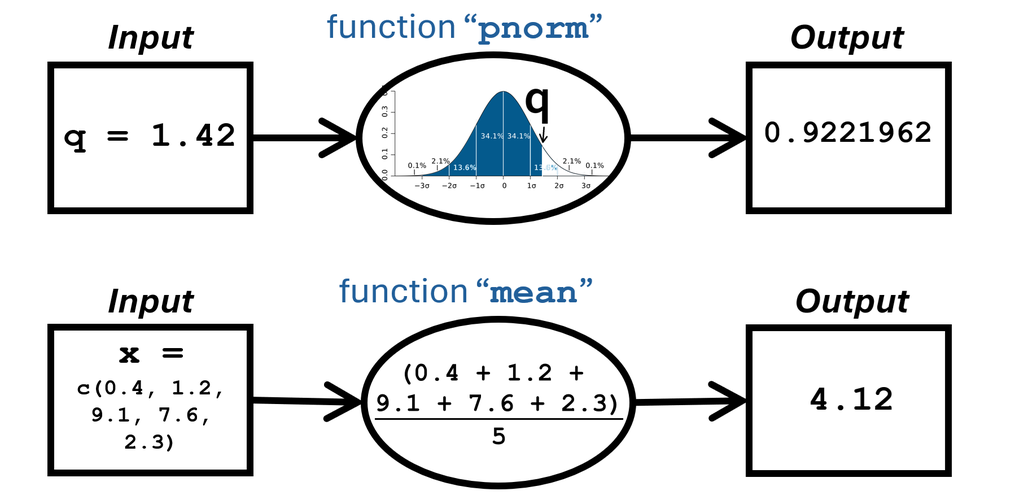

## Functions and arguments

### arguments

- values or variables you pass to a function as input, or to control its behavior

for example, `seq()` generates a sequence of numbers; “`from`” and “`to`” are arguments: it will provide the integers between these two extremes:

```r
seq(from = 3, to = 7)
```

```
[1] 3 4 5 6 7
```

`length.out` controls how many equally spaced numbers must be generated:

```r
seq(from = 3, to = 7, length.out = 4)
```

```
[1] 3.000000 4.333333 5.666667 7.000000
```

alternatively, `by` defines the step size between numbers:

```r
seq(from = 3, to = 7, by = 0.6)
```

```
[1] 3.0 3.6 4.2 4.8 5.4 6.0 6.6
```

## Functions and arguments

### arguments

- values or variables you pass to a function as input, or to control its behavior

`rnorm()` will generate “`n`” random numbers from a normal distribution with “`mean`” as the average and “`sd`” as the standard deviation:

```r
rnorm(n = 5, mean = 100, sd = 15)
```

```
[1]  92.91947 110.38508  90.23376 128.28749 130.30472
```

**Positional matching** - argument names may be omitted if placed in the correct order

```r
rnorm(5, 100, 15)
```

```
[1]  70.08199 101.07961  98.34930 106.68112  98.96034
```

## Functions and arguments

**Default arguments** - a function *might* still work even if some arguments are omitted, if it can use its own *default values* (in this case “`mean=0, sd=1`”)

```r
rnorm(n = 5)
```

```
[1] -1.55287223 -0.04662865  1.11621652 -0.18601975 -0.17616340
```

**Errors** - however, omitting mandatory arguments will result in an *Error*

```r
rnorm(mean = 100, sd = 15)
```

```
Error in rnorm(mean = 100, sd = 15): argument "n" is missing, with no default
```

**Warnings** - some inputs may cause the function to produce *Warnings* and bad output, but they do **not** stop code execution

```r
rnorm(n = 5, mean = 100, sd = -15)
```

```
Warning in rnorm(n = 5, mean = 100, sd = -15): NAs produced
```

```
[1] NaN NaN NaN NaN NaN
```

## Functions and arguments

### Reproducible randomness: `set.seed()`

Random draws normally change from one call to the next:

```r
rnorm(3)
```

```
[1]  0.5992963 -1.2897637 -0.8447426
```

```r
rnorm(3)
```

```
[1] -0.3989080 -0.8489096 -0.1674141
```

Setting the **seed** reproduces the same sequence:

```r
set.seed(42)
rnorm(3)
```

```
[1]  1.3709584 -0.5646982  0.3631284
```

```r
set.seed(42)
rnorm(3)
```

```
[1]  1.3709584 -0.5646982  0.3631284
```

**Tip**

Set the seed once **before a simulation script** if you aim to ensure exact reproducibility (it may not be enough with parallelized computing).

## Functions and arguments

### *HELP!* see the documentation of a function

There are two ways to access documentation: using “`?`” and using `help()`

```r
?rnorm # this will work
help(rnorm) # this does the same
```

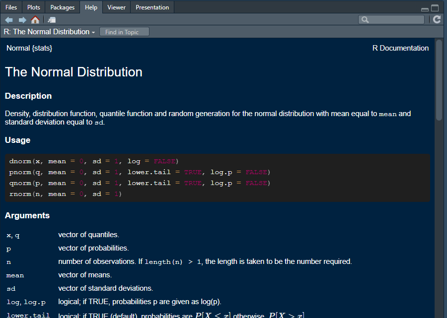

## Some common errors

| Error message | What to check |
| --- | --- |
| `object 'x' not found` | name, or a line not run yet |
| `could not find function "fisherz"` | Load `library(psych)` |
| `there is no package called 'psych'` | Install the package first |
| `unexpected symbol` / `unexpected ')'` | Commas, parentheses, quotes |
| `cannot open file` | File name or path |
| `non-numeric argument to binary operator` | number stored as text? |

Read the message and locate the **first failing line**. RStudio generally stops execution at first error.

## Set up Working Directory

The **Working Directory** (WD) is the location of the folder on your computer where R reads and saves files by default.

Let’s see my own WD using the `getwd()` function:

```r
getwd()
```

```
[1] "C:/Users/enric/Downloads/Basics-R/Slides"
```

If you import/export anything (*data*, *figures*, *workspaces*, etc.) you need to know your WD!

## Set up Working Directory

As a general rule:

- When you open R or the RStudio app, the default WD may be the `documents` folder (in Windows) or the `home directory` (e.g., `/home/username`; in Linux or macOS);
- This default may be changed at any time from inside RStudio via `Tools > Global Options... > General`;
- If you open a file (e.g., a `.R` script) using RStudio, the WD is set to that file’s location (unless the RStudio app was already open before);
- However, you can set a new WD at any time from within the R code, using the **`setwd()`** function, for example:

```r
setwd("C:/Users/enric/")
```

## Set up Working Directory

⚠️ **Windows users**, be careful!

When you copy-and-paste a folder address, Windows will probably take “`\`” as path separator, but “`\`” is the escape character in R, so you will get an error:

```r
setwd("C:\Users\enric\")
```

```
Error: '\U' used without hex digits in character string (<input>:1:11)
```

### How to fix

```r
setwd("C:\\Users\\enric\\")
```

or

```r
setwd( "C:/Users/enric/" )
```

## Absolute vs Relative paths

- **ABSOLUTE paths**: indicate the full path **from the root**, e.g., `"C:/Users/enric/"` (in Linux it might be `"/home/enric/"`; in macOS `"/Users/enric/"`)
- **RELATIVE paths**: indicate the path starting from *(relative to)* the current directory. Most often, you prefer this for import/export, so the same script works on any device; e.g., `"figures/"` or `../figures/`:
  - `png(filename = "figures/Fig1.png")` saves a file `Fig1.png` into `figures`, which is a subfolder **inside** the current WD;
  - `png(filename = "../figures/Fig1.png")` saves a file `Fig1.png` into `figures`, which is a folder **outside, one level up** (`"../"`) from the current WD

## RStudio Projects

**`.Rproj`** may eliminate the need to use `setwd()` within scripts, so you can use only relative paths

- You can create a *new project* in RStudio with `File > New Project...`, choosing a specific folder
- Keep all materials of your project in the same folder as the newly created `.Rproj` file
- As you open the `.Rproj`, it will automatically start a new *RStudio* session with the WD set to that folder.

## RStudio Projects

Opening the `.Rproj` file ensures that RStudio automatically sets the project folder as the working directory, so all files are managed relative to it:

[figure not shown]

## Import/export

Now let’s see how to perform **import/export** operations for:

- **The Workspace**: all objects that exist in your current R session, all results and computations stored so far (see them in the *“Environment” panel* or with `ls()`);
- **Data: SUPER IMPORTANT!** we will focus especially on tabular (Excel-like) data, which we treat as dataframes;
- **Figures**: save your plots for reports and more in `.pdf`, `.png`, and other formats.

## Import/export

### Workspace

All your R code (script) is generally stored in text files with a `.R` extension. But where do you save your results and objects?! Maybe you just don’t…

However, you can export the entire **workspace** using **`save.image()`**

```r
# let's populate the workspace first
N = 100
x = rnorm(N,0,1)
y = 2 + 0.6*x + rnorm(N,0,0.8)
df = data.frame(x, y)
fit = lm(y ~ x, data=df)

# now let's save it
save.image("myWS.RData")
```

*Specifying `"myWS.RData"` is not mandatory but recommended, otherwise your file will simply be named `".RData"`. (By the way… **where** will it be saved?)*

## Import/export

### Workspace

Alternatively, you can save just one or a few workspace objects using **`save()`**

```r
# let's populate the workspace first
N = 100
x = rnorm(N,0,1)
y = 2 + 0.6*x + rnorm(N,0,0.8)
df = data.frame(x, y)
fit = lm(y ~ x, data=df)

# now let's save only two objects
save(df, fit, file="myWS.RData")
```

This will save only objects `df` and `fit` into a newly created file named `myWS.RData`. This is useful when you have an overcrowded workspace and want to save only a few objects containing the final results

## Import/export

### Workspace

Once you open a new R session, you may load the previously stored workspace using the `load()` function, specifying `load("workspace_name.RData")`, like this:

```r
# empty the workspace to make sure there's actually nothing!
rm(list=ls())

# now load the previously saved workspace
load("myWS.RData")

# make sure that the objects have been loaded
ls()
```

## Import/export

### Data

Arguably a **fundamental skill** for anyone working in data science!

Most people use *MS Excel* or similar software (e.g., *LibreOffice Calc*) for handling data, which produce their own file formats (e.g., `.xlsx`). That’s perfectly fine. However… the **most versatile data format is `.csv` (comma-separated values)**, a simple text (no formatting, no licences required) file format for storing tabular data/dataframes.

- **Best practice**: Save data in `.csv` format from your software of choice before importing it into R.

## Import/export

### Data

Here’s an example of using **`read.csv()`** for **importing** data:

```r
# IMPORT csv data from a "data" subfolder, and store it in an object named "df"
df = read.csv("data/Performance.csv")

# OR if you want to be explicit about settings:
df = read.csv("data/Performance.csv", header=TRUE, sep=",", dec=".")

head(df) # have a look at the first few rows
```

```
  id  name anx acc     time
1  1 nydga  20  15 2.077932
2  2 bwknr  14   9 2.436858
3  3 sauuj  18  12 2.549814
4  4 vnjgi  27  15 4.386718
5  5 oueiy  21  11 5.248933
6  6 neebj  12  13 3.463094
```

⚠️ in Italian Excel export settings, the *separator character* (`sep`) may be “`;`” and the *decimal point character* (`dec`) “`,`”, so be aware of your settings!

## Import/export

### Data

If you absolutely want to import your data directly from a **MS Excel** document (`.xlsx`), you may use the function **`read_excel()`** from the package `readxl`:

```r
library(readxl)
df = data.frame( read_excel("data/Performance.xlsx") )
# data.frame() forces it to be a dataframe, otherwise it's a tibble
head(df)
```

```
  id  name anx acc     time
1  1 nydga  20  15 2.077932
2  2 bwknr  14   9 2.436858
3  3 sauuj  18  12 2.549814
4  4 vnjgi  27  15 4.386718
5  5 oueiy  21  11 5.248933
6  6 neebj  12  13 3.463094
```

- You may even import data from an **SPSS** document (`.sav`) using the `read.spss()` function from the `foreign` package

## Import/export

### Data: interactive import

Use **`file.choose()`** to select a file manually:

```r
df = read.csv(file.choose())
```

The **RStudio menu** also offers **File > Import Dataset**, with options for text, Excel and SPSS files.

Keep the resulting import code in your script. A saved relative path makes rerunning the analysis possible without selecting the file again.

## Import/export

### Data

You have processed data with R, now… how to **export** it?

When collaborating with someone also using R, you may choose to exchange data directly by exporting the object or the entire workspace as a `.RData` file, using the `save()` or `save.image()` functions, respectively.

However, if you need to export a dataframe in a more universally readable tabular format, such as `.csv`, you may use **`write.csv()`**:

```r
# specify the dataframe to export (here named "df")
# along with the desired file name, and other arguments
write.csv(df, file="myExportedData.csv")

# if you don't want row numbering / row names
write.csv(df, file="myExportedData.csv", row.names=F)
```

## Import/export

### Figures

R has a collection of functions for exporting figures in different formats: `pdf()`, `png()`, `jpeg()`, `bmp()`, `tiff()`, `svg()`.

Here is an example using `png()`. We use quick base R plots to check data; figure design is covered in the **ggplot2 course**:

```r
# set up a graphic output file named "MyFigure.png" with some settings
png("MyFigure.png", height=1500, width=2000, units="px", res=300)

# code for creating a simple boxplot
boxplot(iris$Sepal.Width)

# close the graphic output file and actually export the plot
dev.off()
```